# R Notebook

Lists are a container that can contain data values of various types

```r
world_series <- list(Winner = Winner, Number.Games = N_Games, Seasons = "2008 to 2017")
```

Access different components of a list. IF we want to display the the number of games played - Number.Games, we can use the list variable name together with the $ symbol and component name

```r
world_series$Number.Games
```

```
 [1] 5 6 5 7 4 7 7 5 7 7
```

```r
#square brackets to display specific item in list
world_series[[2]]
```

```
 [1] 5 6 5 7 4 7 7 5 7 7
```

```r
#The pluck() function from purr also extracts elements from a list
pluck(world_series, "Number.Games")
```

```
 [1] 5 6 5 7 4 7 7 5 7 7
```

```r
#square brackets can also be used
world_series["Number.Games"]
```

```
$Number.Games
 [1] 5 6 5 7 4 7 7 5 7 7
```

Since a data.frame is a list, the dollar sign operator can be used to extract a vector from a data.frame as well The pull() function does the same thing

```r
WS_results$NL_Team
```

```
 [1] PHI PHI SFN SLN SFN SLN SFN NYN CHN LAN
Levels: NYN PHI CHN SLN LAN SFN
```

```r
pull(WS_results, NL_Team)
```

```
 [1] PHI PHI SFN SLN SFN SLN SFN NYN CHN LAN
Levels: NYN PHI CHN SLN LAN SFN
```

R Scripts:

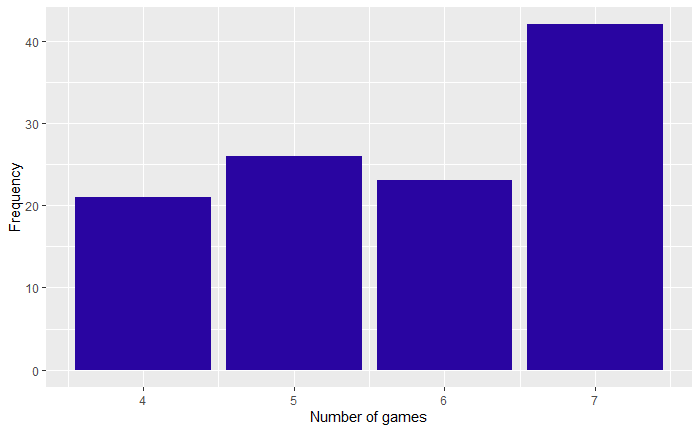

```r
library(tidyverse)
library(Lahman)
ws <- filter(SeriesPost, yearID >= 1903,
             round == "WS", wins + losses < 8)
ggplot(ws, aes(x = wins + losses)) +
  geom_bar(fill = "#2905a1") +
  labs(x = "Number of games", y = "Frequency")
```

Function:

lets create a function to calculate the hr rates for a player over a collection of seasons

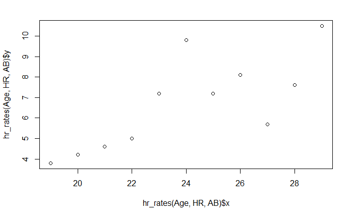

```r
hr_rates <- function(age, hr, ab) {
  rates <- round(100 * hr / ab, 1)
  list(x = age, y = rates)
}

#using data from Mickey Mantle
HR <- c(13, 23, 21, 27, 37, 52, 34, 42, 31, 40, 54)
AB <- c(341, 549, 461, 543, 517, 533, 474, 519, 541, 527, 514)
Age <- 19 : 29


#plot
plot(hr_rates(Age, HR, AB))
```

Writing to a data set:

Create a dataframe and then use write_csv()

```r
hr_rates <- function(age, hr, ab) {
  rates <- round(100 * hr / ab, 1)
  list(x = age, y = rates)
}

HR <- c(13, 23, 21, 27, 37, 52, 34, 42, 31, 40, 54)
AB <- c(341, 549, 461, 543, 517, 533, 474, 519, 541, 527, 514)
Age <- 19 : 29
hr_rates <- hr_rates(Age, HR, AB)
Mantle <- data.frame(Age, HR, AB, Rates = hr_rates$y)

#write to file
write.csv(Mantle, "mantle1.csv")
list.files("data", pattern = "mantle")
```

```
character(0)
```

Lets look at the great HR hitters in baseball history

```r
Batting %>%
  filter(yearID >= 1960, yearID <= 1969) -> Batting_60

#now lets find the total number of home runs for each player in the data frame Batting_60
Batting_60 %>%
  group_by(playerID) %>%
  summarize(HR = sum(HR)) -> hr_60

hr_60 %>%
  arrange(desc(HR)) -> hr_60
head(hr_60)
```

| playerID | HR |
| --- | --- |
| killeha01 | 393 |
| aaronha01 | 375 |
| mayswi01 | 350 |
| robinfr02 | 316 |
| mccovwi01 | 300 |
| howarfr01 | 288 |

```r
NA
```

Now lets iterate an operation using map() Lets find the player who hit the most home runs in each decade across baseball history

```r
#Function that takes data frame of batting statistics and returns one row with the player with the most HRs in that set

hr_leader <- function(data) {
  data %>%
    group_by(playerID) %>%
    summarise(HR = sum(HR)) %>%
    arrange(desc(HR)) %>%
    head(1)
}
#Now we will split the data into pieces based on the decade

Batting %>%
  mutate(decade = 10 * floor(yearID / 10)) %>%
  split(pull(., decade)) %>%
  map_df(hr_leader, .id = "decade")
```

| decade | playerID | HR |
| --- | --- | --- |
| 1870 | pikeli01 | 21 |
| 1880 | stoveha01 | 89 |
| 1890 | duffyhu01 | 83 |
| 1900 | davisha01 | 67 |
| 1910 | cravaga01 | 116 |
| 1920 | ruthba01 | 467 |
| 1930 | foxxji01 | 415 |
| 1940 | willite01 | 234 |
| 1950 | snidedu01 | 326 |
| 1960 | killeha01 | 393 |

[output cut: 5 more lines]

```r
NA
```

```r
Batting %>%
  group_by(playerID) %>%
  summarise(tAB = sum(AB, na.rm = TRUE),
            tHR = sum(HR, na.rm = TRUE),
            tSO = sum(SO, na.rm = TRUE)) -> long_careers
```

```r
Batting_5000 <- filter(long_careers, tAB >= 5000)
head(Batting_5000)
```

| playerID | tAB | tHR | tSO |
| --- | --- | --- | --- |
| aaronha01 | 12364 | 755 | 1383 |
| abreubo01 | 8480 | 288 | 1840 |
| adamssp01 | 5557 | 9 | 223 |
| adcocjo01 | 6606 | 336 | 1059 |
| alfoned01 | 5385 | 146 | 617 |
| allendi01 | 6332 | 351 | 1556 |

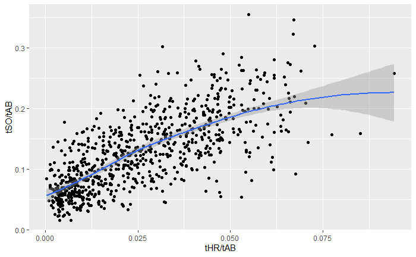

```r
ggplot(Batting_5000, aes(x = tHR / tAB, y = tSO / tAB)) +
  geom_point() + geom_smooth()
```